# Stock risk return analysis

2022-09-19

# Returns of financial stocks

> I would like to study the risk and returns of six different stocks traded on the NYSE. Useful material [finance data sources](https://mam2023.netlify.app/reference/finance_data/).

```r
nyse <- readr::read_csv(here::here("data","nyse.csv"))
```

## The number of companies per sector

```r
#Understanding the data
head(nyse)
```

```
## # A tibble: 6 × 6
##   symbol name                   ipo_year sector            industry      summa…¹
##   <chr>  <chr>                  <chr>    <chr>             <chr>         <chr>
## 1 MMM    3M Company             n/a      Health Care       Medical/Dent… https:…
## 2 ABB    ABB Ltd                n/a      Consumer Durables Electrical P… https:…
## 3 ABT    Abbott Laboratories    n/a      Health Care       Major Pharma… https:…
## 4 ABBV   AbbVie Inc.            2012     Health Care       Major Pharma… https:…
## 5 ACN    Accenture plc          2001     Miscellaneous     Business Ser… https:…
## 6 AAP    Advance Auto Parts Inc n/a      Consumer Services Other Specia… https:…
## # … with abbreviated variable name ¹summary_quote
```

```r
#Creating a table that shows the number of companies per sector, in descending order
descending_sector <- nyse %>%
  dplyr::group_by(sector) %>%
  count(sector) %>%
  arrange(desc(sector))
descending_sector
```

```
## # A tibble: 12 × 2
## # Groups:   sector [12]
##    sector                    n
##    <chr>                 <int>
##  1 Transportation           10
##  2 Technology               40
##  3 Public Utilities         60
##  4 Miscellaneous            12
##  5 Health Care              45
##  6 Finance                  97
##  7 Energy                   42
##  8 Consumer Services        79
##  9 Consumer Non-Durables    31
## 10 Consumer Durables         8
## 11 Capital Goods            45
## 12 Basic Industries         39
```

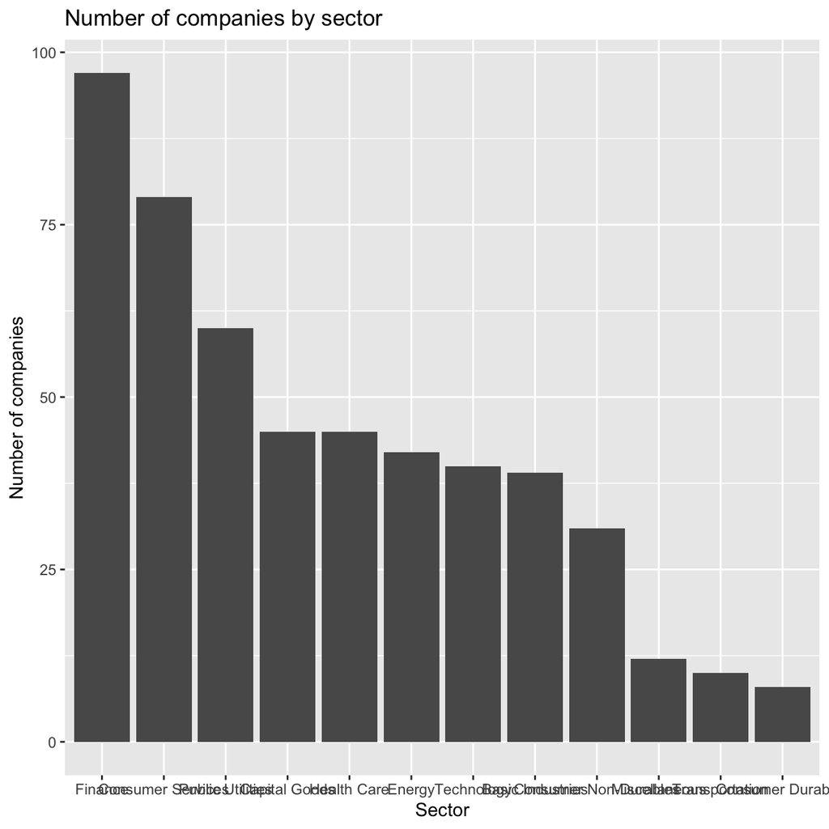

```r
#Creating a bar plot with the number of companies per sector, in descending order

ggplot(descending_sector, aes(x=reorder(sector, -n), y = n)) +
  geom_bar(stat = "identity") +
  labs(title = "Number of companies by sector",
    x = "Sector",
    y = "Number of companies")
```

## Picking stocks

Stocks we chose: `AAPL`, `JPM`, `ANF`, `TSLA`, `XOM`, `SPY`

```r
myStocks <- c("AAPL","JPM","ANF","TSLA","XOM","SPY" ) %>%
  tq_get(get  = "stock.prices",
         from = "2011-01-01",
         to   = "2022-08-31") %>%
  group_by(symbol)

glimpse(myStocks) # examine the structure of the resulting data frame
```

```
## Rows: 17,610
## Columns: 8
## Groups: symbol [6]
## $ symbol   <chr> "AAPL", "AAPL", "AAPL", "AAPL", "AAPL", "AAPL", "AAPL", "AAPL…
## $ date     <date> 2011-01-03, 2011-01-04, 2011-01-05, 2011-01-06, 2011-01-07, …
## $ open     <dbl> 11.6, 11.9, 11.8, 12.0, 11.9, 12.1, 12.3, 12.3, 12.3, 12.4, 1…
## $ high     <dbl> 11.8, 11.9, 11.9, 12.0, 12.0, 12.3, 12.3, 12.3, 12.4, 12.4, 1…
## $ low      <dbl> 11.6, 11.7, 11.8, 11.9, 11.9, 12.0, 12.1, 12.2, 12.3, 12.3, 1…
## $ close    <dbl> 11.8, 11.8, 11.9, 11.9, 12.0, 12.2, 12.2, 12.3, 12.3, 12.4, 1…
## $ volume   <dbl> 4.45e+08, 3.09e+08, 2.56e+08, 3.00e+08, 3.12e+08, 4.49e+08, 4…
## $ adjusted <dbl> 10.05, 10.10, 10.18, 10.18, 10.25, 10.44, 10.42, 10.50, 10.54…
```

## Daily and monthly returns.

```r
#calculate daily returns
myStocks_returns_daily <- myStocks %>%
  tq_transmute(select     = adjusted,
               mutate_fun = periodReturn,
               period     = "daily",
               type       = "log",
               col_rename = "daily_returns",
               cols = c(nested.col))

#calculate monthly  returns
myStocks_returns_monthly <- myStocks %>%
  tq_transmute(select     = adjusted,
               mutate_fun = periodReturn,
               period     = "monthly",
               type       = "arithmetic",
               col_rename = "monthly_returns",
               cols = c(nested.col))

#calculate yearly returns
myStocks_returns_annual <- myStocks %>%
  group_by(symbol) %>%
  tq_transmute(select     = adjusted,
               mutate_fun = periodReturn,
               period     = "yearly",
               type       = "arithmetic",
               col_rename = "yearly_returns",
               cols = c(nested.col))
```

Summarizing monthly returns for each of the stocks and `SPY`; min, max, median, mean, SD.

```r
monthly_returns_summary <- myStocks_returns_monthly %>%
  group_by(symbol) %>%
  summarise(mean_monthly_return = mean (monthly_returns, na.rm=TRUE),
      median_monthly_return = median (monthly_returns, na.rm=TRUE),
      sd_monthly_return = sd (monthly_returns, na.rm=TRUE),
      min_monthly_return = min (monthly_returns, na.rm=TRUE),
      max_monthly_return = max (monthly_returns, na.rm=TRUE))
monthly_returns_summary
```

```
## # A tibble: 6 × 6
##   symbol mean_monthly_return median_monthly_return sd_monthly_…¹ min_m…² max_m…³
##   <chr>                <dbl>                 <dbl>         <dbl>   <dbl>   <dbl>
## 1 AAPL               0.0230                0.0230         0.0791  -0.181   0.217
## 2 ANF                0.00337               0.00105        0.146   -0.421   0.507
## 3 JPM                0.0119                0.0199         0.0727  -0.229   0.202
## 4 SPY                0.0106                0.0146         0.0404  -0.125   0.127
## 5 TSLA               0.0501                0.0117         0.177   -0.224   0.811
## 6 XOM                0.00756               0.00373        0.0697  -0.262   0.241
## # … with abbreviated variable names ¹sd_monthly_return, ²min_monthly_return,
## #   ³max_monthly_return
```

Density plot for each of the stocks:

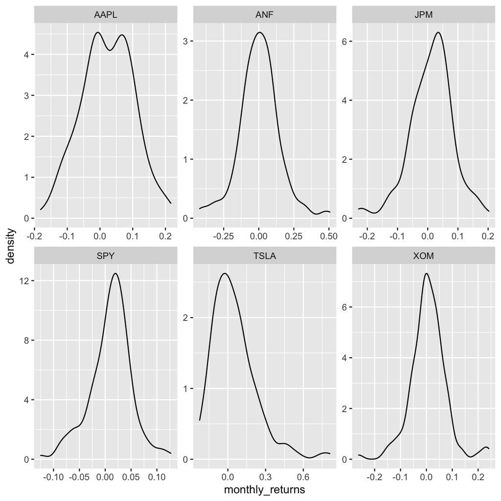

```r
plot1 <- myStocks_returns_monthly %>%
  group_by(symbol) %>%
  ggplot(aes(x = monthly_returns)) +
   facet_wrap(~symbol, scales = "free")+
   geom_density()
plot1
```

## Risk & Return

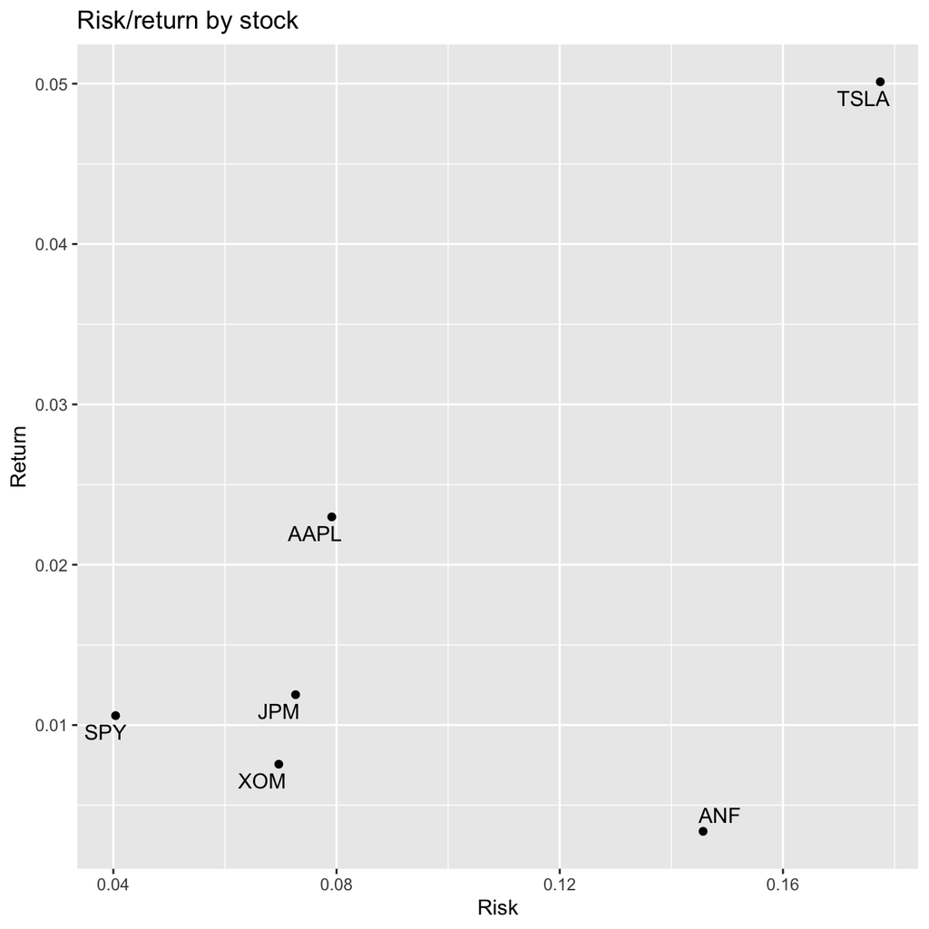

```r
plot2 <- ggplot(data = monthly_returns_summary, mapping = aes(x = sd_monthly_return, y = mean_monthly_return)) +
   geom_point() +
   ggrepel::geom_text_repel(aes(label=symbol))+
   labs(title = "Risk/return by stock",
        x = "Risk",
        y = "Return")
plot2
```

> As we can see based on this plot, higher return is typically correlated with higher risk. However, some stocks, like for example ANF, have higher risk without there being a significant increase in the returns. As an investor, you can use this graph to determine not to invest in a stock like ANF.